# P8105_HW3_HS3163

Hao Sun

10/8/2019

## Problem 1

The goal is to do some exploration of this dataset. To that end, write a short description of the dataset, noting the size and structure of the data, describing some key variables, and giving illstrative examples of observations. Then, do or answer the following (commenting on the results of each):

```r
####Load the data
data("instacart")
###Preping material
DOW_Name = c( "Saturday","Sunday", "Monday", "Tuesday", "Wednesday", "Thursday", "Friday")

###Tidy up the table
instacart_tidy<-instacart%>%
  ###Factorized the aisle, department, and change order_dow into human readable factor
  mutate(
    aisle = forcats::fct_reorder(factor(aisle),aisle_id),
    department = forcats::fct_reorder(factor(department),department_id),
    product_name = forcats::fct_reorder(factor(product_name),product_id),
    ##According to the github hosting the data, 0 = Saturday
    order_dow = order_dow+1,
    order_dow = forcats::fct_reorder(factor(DOW_Name[order_dow]),order_dow)
  )
##Examing which variables are used to uniquely identify each entry.
instacart%>%
  select(order_id, add_to_cart_order)%>%distinct()%>%count()
```

```
## # A tibble: 1 x 1
##         n
##     <int>
## 1 1384617
```

```r
instacart%>%
  select(order_id, product_id)%>%distinct()%>%count()
```

```
## # A tibble: 1 x 1
##         n
##     <int>
## 1 1384617
```

```r
##Check whether order_id and user_id are in 1 to 1 relationship
instacart%>%
  select(order_id,user_id)%>%distinct()%>%count()
```

```
## # A tibble: 1 x 1
##        n
##    <int>
## 1 131209
```

```r
instacart%>%
  select(user_id)%>%distinct()%>%count()
```

```
## # A tibble: 1 x 1
##        n
##    <int>
## 1 131209
```

```r
##Check whether any users have ordered any product more than once within the dataset.
instacart%>%
  select(product_id,user_id)%>%distinct()%>%count()
```

```
## # A tibble: 1 x 1
##         n
##     <int>
## 1 1384617
```

```r
instacart_tidy
```

```
## # A tibble: 1,384,617 x 15
##    order_id product_id add_to_cart_ord… reordered user_id eval_set
##       <int>      <int>            <int>     <int>   <int> <chr>
##  1        1      49302                1         1  112108 train
##  2        1      11109                2         1  112108 train
##  3        1      10246                3         0  112108 train
##  4        1      49683                4         0  112108 train
##  5        1      43633                5         1  112108 train
##  6        1      13176                6         0  112108 train
##  7        1      47209                7         0  112108 train
##  8        1      22035                8         1  112108 train
##  9       36      39612                1         0   79431 train
## 10       36      19660                2         1   79431 train
## # … with 1,384,607 more rows, and 9 more variables: order_number <int>,
## #   order_dow <fct>, order_hour_of_day <int>,
## #   days_since_prior_order <int>, product_name <fct>, aisle_id <int>,
## #   department_id <int>, aisle <fct>, department <fct>
```

This data set has 1,384,617 entries with 15 variables.Each entry enssentially records the addition of one product to the basket of one order, and was uniquely identified by the combination of order_id and add_to_cart_order or product_id. Among the variables, “order_id”, and “add_to_cart_order” are used to identify each records. Considering the potential incidents of adding one product twice to the cart, granted not recorded in this dataset,“product_id” shall not be treated as a part of the index variables. Instead, “product_id” alone with “aisle_id” and “department_id” are metadata describing the content of each addition of one product. “product_name”, “aisle” and “department” respectifully lable the aforementioned metadata for human readablity. Besides, “reordered”,“order_number”,“order_dow”,“days_since_prior_order” describe each orders’ temperal attributes, from which comsumer behavior estimation may be derived. “eval_set” variables described the portion of the dataset among the original instacart data collections, and are not relevent to our analysis.

It is worth mentioned that in the dataset, no user_id are associated with more than one order_id. After examning the full instacart collection, it was revealed that only one order from each user was added to the train eval_set. This data set also did not included the quantity of each product purchased. For instance, for the order with order_id 1, it was shown that the user,whose id is 112108m, added 8 products, ranging from “Bulgarian Yogurt” to “Organic Whole String Cheese”, but there is not information indicating, say, the number of bottles of Bulgarian Yogurt the user bought.

- How many aisles are there, and which aisles are the most items ordered from? **Answer** There are 134 aisles in the data set.

```r
#Finding which aisles are the most items ordered from
instacart_tidy%>%
##Count the number of items added to order from each aisles.
  count(aisle)%>%
##Finding the aisle that is correlated to the most items added to order from each aisles.
  filter(n == max(n))%>%
  pull(aisle)%>%as.character()
```

```
## [1] "fresh vegetables"
```

The fresh vegetable is the aisle the most items ordered from

It occurs that out of the 134 aisles, fresh vegetable is the aisle with the most item ordered from. This result is consistent with the logo, a carrot, and one of its advertising images on Apple AppStore, a bag of fresh vegetables, used by instacart APP.

- Make a plot that shows the number of items ordered in each aisle, limiting this to aisles with more than 10000 items ordered. Arrange aisles sensibly, and organize your plot so others can read it.

**Answer**

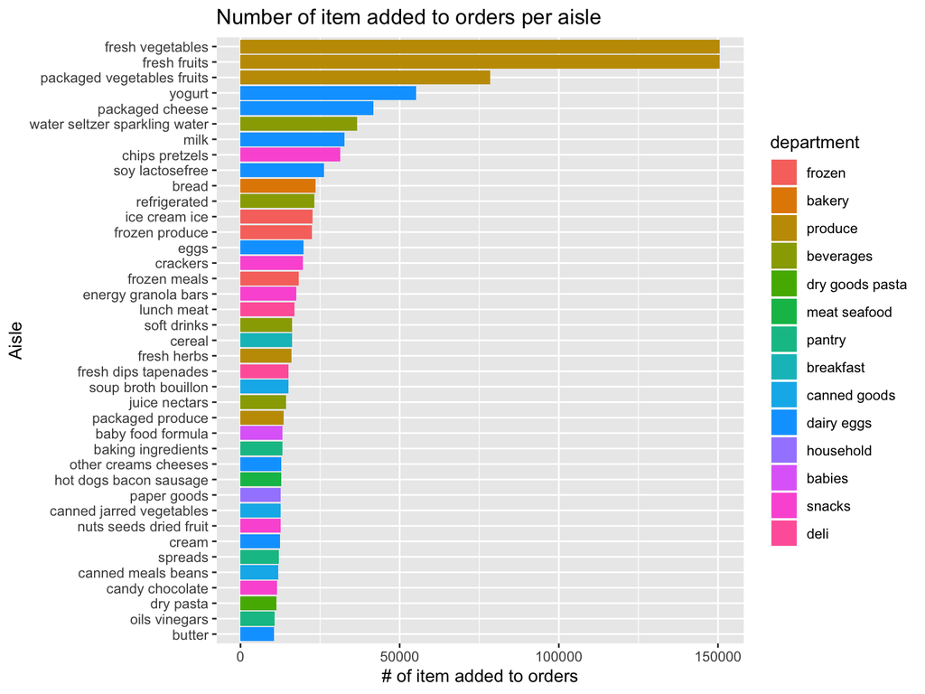

```r
instacart_tidy%>%
##Count the number of items added to order from each aisles, label each aisle alone with the department it belonged to.
  group_by(department,aisle)%>%
  summarise(n())%>%
  group_by(department)%>%
  ##Rename the n() column
  mutate(items_ordered_from = `n()`)%>%
  select(-`n()`)%>%
##Finding the aisle with more than 10000 purchases.
  filter(items_ordered_from >= 10000)%>%
  ##Order the aisle by the number of its sales, also labed each aisle for their correspond department
  ggplot(aes(x = reorder(aisle,items_ordered_from),
             y = items_ordered_from ,
             fill = department))+
  geom_col()+
  labs(
    title = "Number of item added to orders per aisle",
    x = "Aisle",
    y = "# of item added to orders"
  )+
##Flip the graph so that the name of each aisle become visible
  coord_flip()
```

The first three most popular aisles, and by large margins, are fresh vegetables, fresh fruits, and package vegetable fruits. All of the three aisles are from the produce department, which generally implies that “the products are fresh and in the same state as where and when they were harvested.” It turns out that the users included in this dataset primarily rely on instacart to the acquired fresh products. It makes senes to order fresh products only when they are about to be consumed. Otherwise, it defeats the purpose of ordering fresh food. Therefore users are more likely to order items from the produce department in a different order, and, due to the lack of a “quantities per order” variable, inflate the popularity.

- Make a table showing the three most popular items in each of the aisles “baking ingredients”, “dog food care”, and “packaged vegetables fruits”. Include the number of times each item is ordered in your table.

```r
instacart_tidy%>%
  filter(aisle == "baking ingredients" | aisle == "dog food care"  | aisle == "packaged vegetables fruits" )%>%
##Count the number of items added to order from each aisles.
  count(aisle,product_name)%>%
  group_by(aisle)%>%
  arrange(desc(n),.by_group = TRUE)%>%
##Finding the top 3 most sold item from each aisle
filter(n>=
  ##Finding the largest among
    max(
    ##Among  n
      n[
    ##that is neither the second largest
      n!=max(n[n!=max(n)]) &
    ##Nor the first largest
      n!=max(n)]
      ))%>%
  knitr::kable()
```

[output not shown]

- Make a table showing the mean hour of the day at which Pink Lady Apples and Coffee Ice Cream are ordered on each day of the week; format this table for human readers (i.e. produce a 2 x 7 table).

```r
instacart_tidy%>%
##Select anything that fell in the catagory of Pink Lady Apples or Coffee Ice Cream
  filter(str_detect(product_name,'Pink Lady Apples') | str_detect(product_name,'Coffee Ice Cream') )%>%
##Aggregate similar products
  mutate(product_name =
           replace(
             product_name,
             str_detect(product_name,'Pink Lady Apples'),
            'Pink Lady Apples'))%>%
    mutate(product_name =
           replace(
             product_name,
             str_detect(product_name,'Coffee Ice Cream'),
            'Coffee Ice Cream'))%>%
##Count the number of items added to order from each aisles.
  group_by(product_name,order_dow)%>%
  summarise(`mean hour of the day` = mean(order_hour_of_day))%>%
  mutate(`mean hour of the day` = round(`mean hour of the day`) )%>%
  pivot_wider(names_from = order_dow, values_from = `mean hour of the day`)%>%
    knitr::kable()
```

[output not shown]